# Лабораторная работа №4

Математическое моделирование

Байрамгельдыев Довлетмурат

Российский университет дружбы народов, Москва, Россия

28 февраля 2023

# Информация

## Докладчик

- Байрамгельдыев Довлетмурат
- студент 3 курса группы НФИбд-01-20
- ст. б. 1032207470
- Российский университет дружбы народов
- 1032207470@pfur.ru

# Вводная часть

## Актуальность

- Решение с помощью программных средств - наиболее распространенный на данный момент подход в решении дифференциальных уравнений. Освоение методов построения математической модели и вариантов ее программной реализации лежит в основе математического моделирования любых систем.
- Julia и OpenModelica - языки программирования, созданные для математических вычислений но использующие разные концепции (императивную и декларативную), являются распространенными инструментами для моделирования.

## Объект и предмет исследования

- Языки научного программирования Julia и OpenModelica
- Фазовые портреты гармонического осциллятора

## Цели и задачи

- Изучить уравнение описывающее поведение гармонического осциллятора
- Построить фазовые портреты рассматриваемых осцилляторов

## Материалы и методы

# Ход работы

## Три случая колебаний гармонического осциллятора

Модель для первого случая: $\begin{cases}\dot{x} = y\\\dot{y} = -\omega_{0}^{2}x\end{cases}$

Модель для второго случая: $\begin{cases}\dot{x} = y\\\dot{y} = -2\gamma\dot{x}-\omega_{0}^{2}x\end{cases}$

Модель для третьего случая: $\begin{cases}\dot{x} = y\\\dot{y} = P(t)-2\gamma\dot{x}-\omega_{0}^{2}x\end{cases}$

## Программа на языке Julia, 1

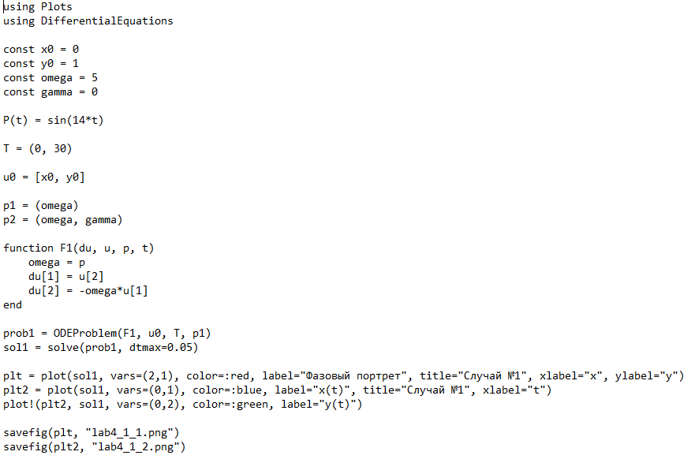

## Фазовый портрет на языке Julia, 1

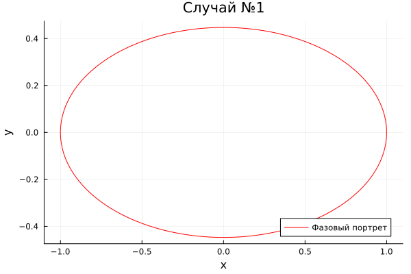

## Решение уравнения на языке Julia, 1

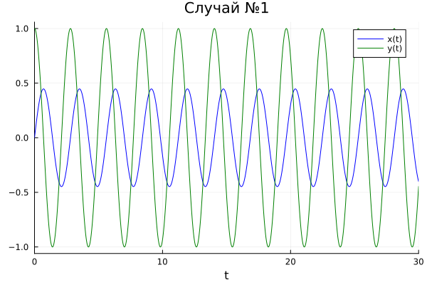

## Программа на языке Julia, 2

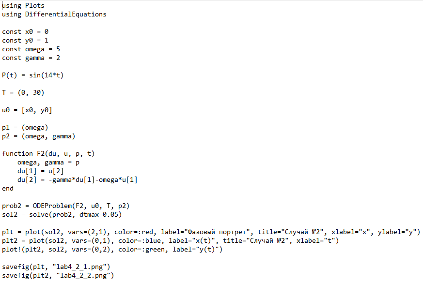

## Фазовый портрет на языке Julia, 2

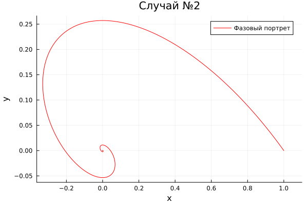

## Решение уравнения на языке Julia, 2

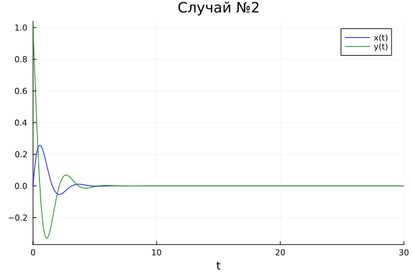

## Программа на языке Julia, 3

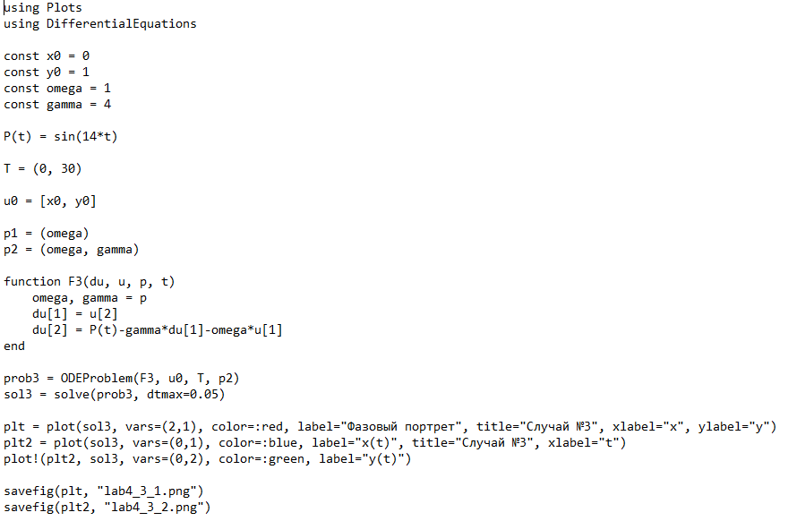

## Фазовый портрет на языке Julia, 3

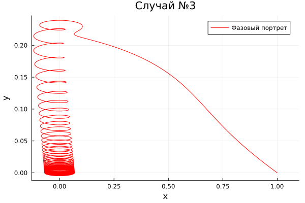

## Решение уравнения на языке Julia, 3

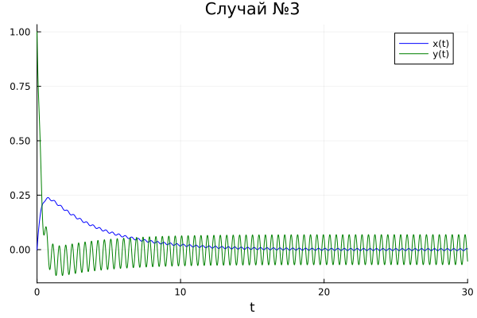

## Программа на языке OpenModelica, 1

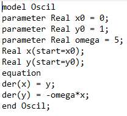

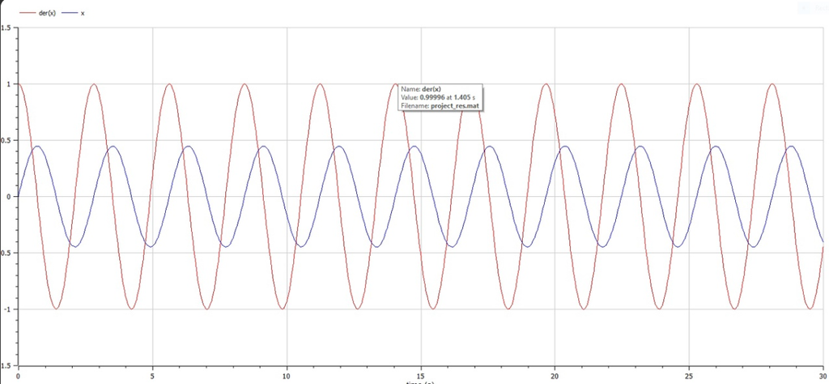

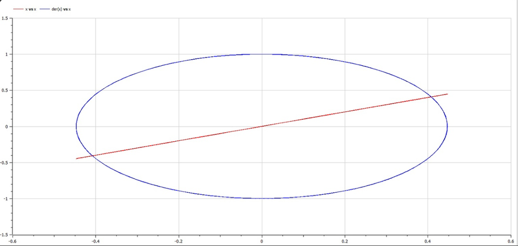

## Программа на языке OpenModelica, 2

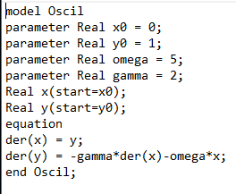

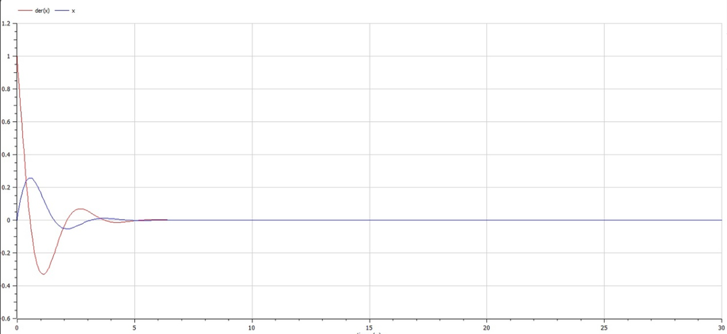

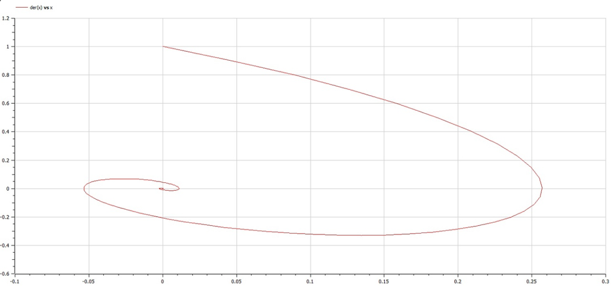

## Программа на языке OpenModelica, 3

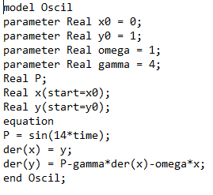

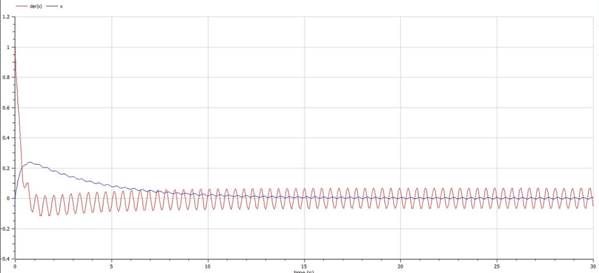

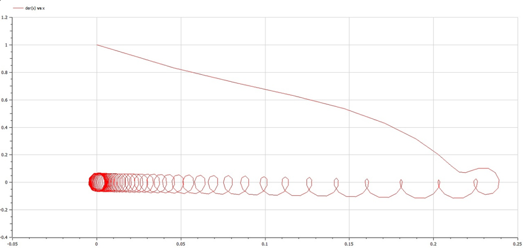

# Результаты

## Результаты работы

- Приобретены навыки работы с Julia и OpenModelica
- Построена модель колебаний гармонического осциллятора
- Построены графики фазового портрета и решения уравнения гармонического осциллятора
- OpenModelica — более подходящий язык для работы с данной моделью-